# Summary Analysis of Fire severity impact on understory vegetation species richness in the Araucaria-Nothofagus forest.

Peter Pham

*[Preface: The client was interested in exploring the effects of wildfires on recovering areas. Of particular interest was to develop a model that would describe the relationship between burn severity and species richness. As such, the first step in the process is conducting a hypothesis test to gain a broad understanding of the data. The analysis conducted in this document is a summary excerpt from the full report, formatted for portfolio purposes*

## Data Cleaning

- Data is fragmented
- Formats Used
- Data Points of Interest

## Exploratory Analysis

Exploratory analysis is conducted to gain a stronger sense in which the data is collected. Mean species richness for each burn severity group are slightly different from each other (unburned (UN): $\mu = 4.84$, low-burned (L): $\mu = 3.43$, high-burned (H): $\mu = 2.11$). The spread and mean of each group’s species richness can be easily compared with a side-by-side box plot:

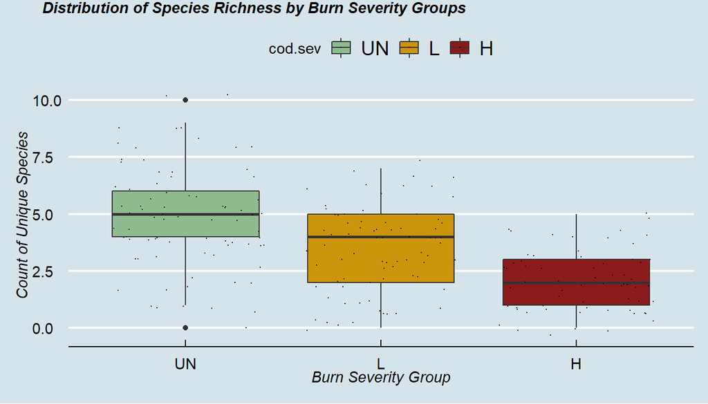

Distributions of Unique Specices by Burn Severity

```r
# Creating a boxplot for the groups
bp = ggplot(dt2, aes(y = species, fill = cod.sev,
    x = cod.sev)) + geom_boxplot() + geom_jitter(color = "black",
    size = 0.1, alpha = 0.9) + theme_economist() +
    scale_fill_manual(values = c("darkseagreen",
        "darkgoldenrod3", "firebrick4")) +
    labs(y = expression(italic("Count of Unique Species")),
        x = expression(italic("Burn Severity Group")),
        subtitle = expression(bold("")))

# Boxplot Annotation
annotate_figure(bp, fig.lab = "Distribution of Species Richness by Burn Severity Groups",
    fig.lab.face = "bold.italic", fig.lab.pos = "top.left")
```

In the box plot above, we can see this relative distribution of species richness from the burn categories. The unburned group as the largest spread of species richness (minimum value = 0, maximum value = 10). As we move to the right, not only does the mean decrease, but so does the overall spread of recorded species. Though we can get some semblance of the differences between the groups, it would be useful to generate a table to look at the specific values and how they change as the burn classification changes.

We generate a table using the code below:

```r
# Table 1: Summary Statistics for groups
summary = dt2 %>% # Produce summary statistics by burn group
  group_by(cod.sev) %>%
  summarise(Minimum = min(species),
                    Q1 = quantile(species, 0.25),
                    Median = median(species),
                    Mean = mean(species),
                    S.Error = sd(species)/sqrt(length(species)),
                    S.D. = sd(species),
                    Q3 = quantile(species, 0.75),
                    Maximum = max(species))

# Using KableExtra package to clean up table data and to add styling options
kable(summary,
      caption =
        "Summary Statistics for Species Richness by Burn Severity",
      col.names = c("Burn Severity", names(summary)[-1]),
      align="c",
      booktabs = T,
      digits=2) %>%
kable_styling(position = "center",
      full_width = F,
      latex_options="hold_position") %>%
      row_spec(0, bold=TRUE)
```

Summary Statistics for Species Richness by Burn Severity

| Burn Severity | Minimum | Q1 | Median | Mean | S.Error | S.D. | Q3 | Maximum |
| --- | --- | --- | --- | --- | --- | --- | --- | --- |
| UN | 0 | 4 | 5 | 4.84 | 0.25 | 2.20 | 6 | 10 |
| L | 0 | 2 | 4 | 3.43 | 0.21 | 1.86 | 5 | 7 |
| H | 0 | 1 | 2 | 2.11 | 0.16 | 1.30 | 3 | 5 |

Finally, we use a histogram to gain a clearer sense of each groups’ distribution. Recognizing how each group is distributed gives us some notion what what tools we are able to use. We generate a side-by-side histogram with an overlaid curve to approximate the shape of each groups distribution:

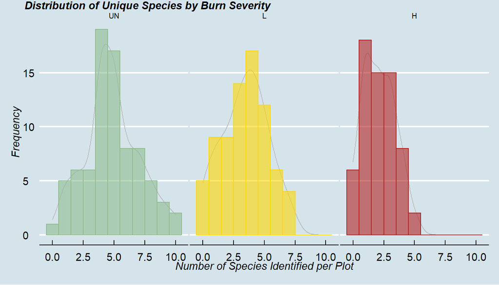

Indidividual Distribution of Each Burn Category

```r
hg.all = dt2 %>%
    mutate(cod.sev = fct_reorder(cod.sev,
        species, .desc = TRUE)) %>%
    ggplot(aes(x = species, fill = cod.sev,
        color = cod.sev)) + geom_density(color = "gray",
    size = 0.5, alpha = 0, aes(y = ..count..)) +
    geom_histogram(binwidth = 1, alpha = 0.6,
        position = "identity") + scale_fill_manual(values = c("darkseagreen",
    "gold", "firebrick")) + scale_color_manual(values = c("darkseagreen",
    "gold", "firebrick")) + theme_economist() +
    theme(legend.position = "none", panel.spacing = unit(0.1,
        "lines"), strip.text.x = element_text(size = 8)) +
    xlab(expression(italic("Number of Species Identified per Plot"))) +
    ylab(expression(italic("Frequency"))) +
    facet_wrap(~cod.sev)

# Annotate Figure
annotate_figure(hg.all, fig.lab = "Distribution of Unique Species by Burn Severity",
    fig.lab.face = "bold.italic", fig.lab.pos = "top.left")
```

At first glance, each group appears to be approximately bell-shaped. However, it’s clear that each group is not symmetric and has strong peaks towards the center of the distribution. From the steps taken in the exploratory analysis, it is unclear if each group is normally distributed. If that is the case, than it is likely that a non-parametric method will be applied here.

## Methods

We look to test if the mean species richness of each burn group is significantly different. We use Shapiro-Wilk’s test to verify if each burn group’s distribution is normally distributed or not. The null hypothesis of the Shapiro-Wilks test states that the distributions are normal. Thus, if we reject the null hypothesis, then the distributions in interest are not normal. We conduct that test at $\alpha$ = 0.05:

```r
sw.all = dt2 %>%
    dplyr::group_by(cod.sev) %>%
    dplyr::summarize(N = length(species),
        Test.Stat = shapiro.test(species)$statistic,
        P.Value = shapiro.test(species)$p.value)

# Using KableExtra package to clean up
# table data and to add styling options
kable(sw.all, caption = "Shapiro-Wilks Test for All Groups",
    col.names = c("Burn Severity", "N Observations",
        "Test Stat", "P-Value"), align = "c",
    booktabs = T, digits = 3) %>%
    kable_styling(position = "center", full_width = F,
        latex_options = "hold_position") %>%
    row_spec(0, bold = TRUE)
```

Shapiro-Wilks Test for All Groups

| Burn Severity | N Observations | Test Stat | P-Value |
| --- | --- | --- | --- |
| UN | 80 | 0.969 | 0.047 |
| L | 76 | 0.958 | 0.013 |
| H | 64 | 0.929 | 0.001 |

The table above describes the results of our Shapiro-Wilks test. At $\alpha$ = 0.05, we reject the null hypothesis for every group and conclude that each burn group is not normal. Generally, for normal results, we would proceed with an ANOVA. However; since we have clear non-normality, we will use the Kruskal-Wallis ranked means test - the non-parametric counterpart to an ANOVA. We begin by defining the hypothesis:

$H_0$ = there does not exist a difference in the ranked means between each burn severity group

$H_1$ = there does exist a difference in the ranked means between each burn severity group

The Kruskal-Wallis will let us know if there is at least one ranked mean that is different from the other groups. If a difference does exist, we will want to know the extent and magnitude of that difference. For that purpose, we will use Dunn’s post-hoc test to examine the differences in ranked mean, if they exist at all.

## Results/Conclusions

At the 95% confidence level ($\alpha$ = 0.05), we test if the ranked means of each burn group are significantly different:

```r
# Kruskal-Wallace
kw = kruskal.test(species ~ cod.sev, data = dt2)
kw
```

```
##
##  Kruskal-Wallis rank sum test
##
## data:  species by cod.sev
## Kruskal-Wallis chi-squared = 58.907, df = 2, p-value = 1.616e-13
```

With two degrees of freedom, we produce a test statistics of 58.91 and a p-value of $1.616 x 10^-13$. Since the p-value is less than our set alpha ($\alpha$ = 0.05), we reject the null hypothesis and conclude that there does exist at least one ranked mean that is significantly different than the others.

To examine the extent of that difference, we proceed with Dunn’s post hoc test at the 95% confidence level ($\alpha$ = 0.05):

```r
# Post Hoc Analysis
dunn = dunn.test(dt2$species, g = dt2$cod.sev,
    kw = TRUE, list = TRUE)
```

```
##   Kruskal-Wallis rank sum test
##
## data: x and group
## Kruskal-Wallis chi-squared = 58.907, df = 2, p-value = 0
##
##
##                            Comparison of x by group
##                                 (No adjustment)
## Col Mean-|
## Row Mean |          H          L
## ---------+----------------------
##        L |  -4.110901
##          |    0.0000*
##       UN |  -7.674090  -3.680515
##          |    0.0000*    0.0001*
##
##
## List of pairwise comparisons: Z statistic (p-value)
## ----------------------------
## H - L  : -4.110901 (0.0000)*
## H - UN : -7.674090 (0.0000)*
## L - UN : -3.680515 (0.0001)*
##
## alpha = 0.05
## Reject Ho if p <= alpha/2
```

```r
dunn.table = cbind.data.frame(dunn$comparisons,
    dunn$Z, dunn$P.adjusted)
dunn.table[order(dunn.table$"dunn$P.adjusted"),
    ]
```

```
##   dunn$comparisons    dunn$Z dunn$P.adjusted
## 2           H - UN -7.674090    8.329851e-15
## 1            H - L -4.110902    1.970583e-05
## 3           L - UN -3.680516    1.163813e-04
```

```r
# Using KableExtra package to clean up
# table data and to add styling options
kable(dunn.table, caption = "Dunn's Pairwise Test for Burn Severity Groups",
    col.names = c("Group Comparisons", "Test Statistic",
        "P-Value"), align = "c", booktabs = T,
    digits = 4) %>%
    kable_styling(position = "center", latex_options = "hold_position") %>%
    row_spec(0, bold = TRUE)
```

Dunn’s Pairwise Test for Burn Severity Groups

| Group Comparisons | Test Statistic | P-Value |
| --- | --- | --- |
| H - L | -4.1109 | 0e+00 |
| H - UN | -7.6741 | 0e+00 |
| L - UN | -3.6805 | 1e-04 |

The Dunn’s test yields p-values that are all less than our set alpha ($\alpha$ = 0.5) and we reject the null hypothesis.

Thus, through Kruskal-Wallis and Dunn’s test, we can conclude that each mean is significantly different from each other. Further more, we can confirm that each mean is significantly smaller than each other.

## Recommendations

The non-parametric methods used above indicates that the species diversity that occurred in plots following the wildfires are significantly less diverse than before. This information may lend itself well to rehabilitation efforts of forest lands impacted by these events. Generally, regression modeling would follow this test, but multiple fittings with given data have rendered poor models. This may be due to the relatively small sample size, the data collection controls used, or missing variables that are not represented in the data set.

It is recommended that next steps would be to continue collecting high-quality data of the region. An increase of sample data points as well as more variables may include important inform to better understand the relationship that occurs with plan species diversity in these areas. Additionally, the potential for a high-quality model to be produced may be pivotal to predicting the impact of future wildlife events. With the onset of global warming conditions, wildfire conditions may be exacerbated. Being better prepared for these potential outcomes may lead to improved forest and environmental health.